# RNA-seq Analysis in R

## Retrieving Genomic Locations

It might seem natural to add genomic locations to our annotation table, and possibly a bit odd that the `org.Mm.eg.db` package does not supply such mappings. In fact, there is a whole suite of package for performing this, and more-advanced queries that relate to the location of genes. These are listed on the Bioconductor [annotation page](http://bioconductor.org/packages/release/BiocViews.html#___AnnotationData) and have the prefix `TxDb.`

The package we will be using is `TxDb.Mmusculus.UCSC.mm10.knownGene`. Packages are available for other organisms and genome builds. It is even possible to *build your own database* if one does not exist. See `vignette("GenomicFeatures")` for details

```r
source("http://www.bioconductor.org/biocLite.R")
biocLite("TxDb.Mmusculus.UCSC.mm10.knownGene")

## For Humans
biocLite("TxDb.Hsapiens.UCSC.hg19.knownGene")
```

We load the library in the usual fashion and create a new object to save some typing. As with the `org.` packages, we can query what columns are available with `columns`,

```r
library(TxDb.Mmusculus.UCSC.mm10.knownGene)
tx <- TxDb.Mmusculus.UCSC.mm10.knownGene
columns(tx)
```

```
 [1] "CDSCHROM"   "CDSEND"     "CDSID"      "CDSNAME"    "CDSSTART"   "CDSSTRAND"  "EXONCHROM"  "EXONEND"    "EXONID"     "EXONNAME"   "EXONRANK"
[12] "EXONSTART"  "EXONSTRAND" "GENEID"     "TXCHROM"    "TXEND"      "TXID"       "TXNAME"     "TXSTART"    "TXSTRAND"   "TXTYPE"
```

The `select` function is used in the same manner as the `org.Mm.eg.db` packages.

## Challenge

> Use the TxDb.Mmusculus.UCSC.mm10.knownGene package to retrieve the exon coordinates for the genes `50916`, `110308`, `12293`

| GENEID | EXONCHROM | EXONSTART | EXONEND |
| --- | --- | --- | --- |
| 50916 | chr13 | 73260497 | 73260876 |
| 50916 | chr13 | 73264848 | 73264979 |
| 50916 | chr13 | 73265458 | 73265709 |
| 50916 | chr13 | 73266596 | 73266708 |
| 50916 | chr13 | 73267504 | 73267832 |
| 50916 | chr13 | 73268226 | 73269620 |
| 110308 | chr15 | 101712274 | 101712891 |
| 110308 | chr15 | 101711529 | 101711743 |
| 110308 | chr15 | 101710739 | 101710799 |
| 110308 | chr15 | 101710536 | 101710631 |

[output cut: 48 more lines]

### Overview of GenomicRanges

One of the real strengths of the `txdb..` packages is the ability of interface with `GenomicRanges`, which is the object type used throughout Bioconductor [to manipulate Genomic Intervals](https://www.ncbi.nlm.nih.gov/pmc/articles/PMC3738458/pdf/pcbi.1003118.pdf).

These object types permit us to perform common operations on intervals such as overlapping and counting. We can define the chromosome, start and end position of each region (also strand too, but not shown here).

```r
library(GenomicRanges)
simple.range <-GRanges("1", IRanges(start=1000,end=2000))
simple.range
```

```
GRanges object with 1 range and 0 metadata columns:
      seqnames       ranges strand
         <Rle>    <IRanges>  <Rle>
  [1]        1 [1000, 2000]      *
  -------
  seqinfo: 1 sequence from an unspecified genome; no seqlengths
```

We don’t have to have all our ranges located on the same chromosome

```r
chrs <- c("chr13", "chr15","chr5")
start <- c(73000000, 101000000, 15000000)
end <- c(74000000,102000000, 16000000)
my.ranges <- GRanges(rep(chrs,3),
                     IRanges(start=rep(start,each=3),
                             end = rep(end,each=3))
)
```

There are a number of useful functions for calculating properties of the data (such as *coverage* or sorting). Not so much for RNA-seq analysis, but `GenomicRanges` are used throughout Bioconductor for the analysis of NGS data.

```r
keys <- c("50916","110308","12293")
genePos <- select(tx, keys=keys,
       keytype = "GENEID",
       columns=c("EXONCHROM","EXONSTART","EXONEND")
      )
geneRanges <- GRanges(genePos$EXONCHROM, IRanges(genePos$EXONSTART,genePos$EXONEND), GENEID=genePos$GENEID)
geneRanges
```

```
GRanges object with 58 ranges and 1 metadata column:
       seqnames               ranges strand |      GENEID
          <Rle>            <IRanges>  <Rle> | <character>
   [1]    chr13 [73260497, 73260876]      * |       50916
   [2]    chr13 [73264848, 73264979]      * |       50916
   [3]    chr13 [73265458, 73265709]      * |       50916
   [4]    chr13 [73266596, 73266708]      * |       50916
   [5]    chr13 [73267504, 73267832]      * |       50916
   ...      ...                  ...    ... .         ...
  [54]     chr5 [16370558, 16374511]      * |       12293
  [55]     chr5 [16341990, 16342010]      * |       12293
  [56]     chr5 [16326327, 16326383]      * |       12293
  [57]     chr5 [16322539, 16322595]      * |       12293
  [58]     chr5 [16267376, 16268604]      * |       12293
  -------
  seqinfo: 3 sequences from an unspecified genome; no seqlengths
```

```r
findOverlaps(my.ranges,geneRanges)
```

```
Hits object with 16 hits and 0 metadata columns:
       queryHits subjectHits
       <integer>   <integer>
   [1]         1           1
   [2]         1           2
   [3]         1           3
   [4]         1           4
   [5]         1           5
   ...       ...         ...
  [12]         5          12
  [13]         5          13
  [14]         5          14
  [15]         5          15
  [16]         9          16
  -------
  queryLength: 9 / subjectLength: 58
```

```r
seqlevelsStyle(geneRanges)
```

```
[1] "UCSC"
```

```r
seqlevelsStyle(simple.range)
```

```
[1] "NCBI"    "Ensembl" "MSU6"    "AGPvF"
```

## Retrieving Gene Coordinates as GenomicRanges

As we saw above, it is quite straightforward to translate the output of a `select` query into a `GenomicFeatures` object. However, several convenience functions exist to retrieve the structure of every gene for a given organism in one object.

The output of `exonsBy` is a list, where each item in the list is the exon co-ordinates of a particular gene.

```r
exo <- exonsBy(tx,"gene")
exo
```

```
GRangesList object of length 24116:
$100009600
GRanges object with 7 ranges and 2 metadata columns:
      seqnames               ranges strand |   exon_id   exon_name
         <Rle>            <IRanges>  <Rle> | <integer> <character>
  [1]     chr9 [21062393, 21062717]      - |    134539        <NA>
  [2]     chr9 [21062894, 21062987]      - |    134540        <NA>
  [3]     chr9 [21063314, 21063396]      - |    134541        <NA>
  [4]     chr9 [21066024, 21066377]      - |    134542        <NA>
  [5]     chr9 [21066940, 21067925]      - |    134543        <NA>
  [6]     chr9 [21068030, 21068117]      - |    134544        <NA>
  [7]     chr9 [21073075, 21075496]      - |    134546        <NA>

$100009609
GRanges object with 6 ranges and 2 metadata columns:
      seqnames               ranges strand | exon_id exon_name
  [1]     chr7 [84940169, 84941088]      - |  109989      <NA>
  [2]     chr7 [84943141, 84943264]      - |  109990      <NA>
  [3]     chr7 [84943504, 84943722]      - |  109991      <NA>
  [4]     chr7 [84946200, 84947000]      - |  109992      <NA>
  [5]     chr7 [84947372, 84947651]      - |  109993      <NA>
  [6]     chr7 [84963816, 84964009]      - |  109994      <NA>

$100009614
GRanges object with 1 range and 2 metadata columns:
      seqnames               ranges strand | exon_id exon_name
  [1]    chr10 [77711446, 77712009]      + |  143986      <NA>

...
<24113 more elements>
-------
seqinfo: 66 sequences (1 circular) from mm10 genome
```

To access the structure of a particular gene, we can use the `[[` syntax with the name of the gene (Entrez gene ID) within quote marks. If we wanted to whole region that the gene spans we could use the `range` function.

```r
range(exo[["110308"]])
```

```
GRanges object with 1 range and 0 metadata columns:
      seqnames                 ranges strand
         <Rle>              <IRanges>  <Rle>
  [1]    chr15 [101707070, 101712891]      -
  -------
  seqinfo: 66 sequences (1 circular) from mm10 genome
```

## Exporting tracks

It is also possible to save the results of a Bioconductor analysis in a browser to enable interactive analysis and integration with other data types, or sharing with collaborators. For instance, we might want a browser track to indicate where our differentially-expressed genes are located. We shall use the `bed` format to display these locations. We will annotate the ranges with information from our analysis such as the fold-change and significance.

First we create a data frame for just the DE genes.

```r
sigGenes <- results.annotated[detags,]
sigGenes
```

|  | logFC | logCPM | LR | PValue | FDR | ENTREZID | SYMBOL | GENENAME |
| --- | --- | --- | --- | --- | --- | --- | --- | --- |
| 497097 | -10.947240 | 2.523651483 | 23.590694 | 1.191624e-06 | 0.0004377961 | 497097 | Xkr4 | X-linked Kx blood group related 4 |
| 20671 | -2.673131 | 1.241863995 | 10.587241 | 1.138708e-03 | 0.0078553551 | 20671 | Sox17 | SRY (sex determining region Y)-box 17 |
| 58175 | 4.471434 | 1.124011467 | 14.373441 | 1.499018e-04 | 0.0020196485 | 58175 | Rgs20 | regulator of G-protein signaling 20 |
| 76187 | 3.033003 | 2.407101262 | 8.475630 | 3.599356e-03 | 0.0182496716 | 76187 | Adhfe1 | alcohol dehydrogenase, iron containing, 1 |
| 72481 | 2.136618 | -0.247275169 | 6.137581 | 1.323382e-02 | 0.0468231045 | 72481 | 2610203C22Rik | RIKEN cDNA 2610203C22 gene |
| 329093 | -9.262471 | 0.795143081 | 22.116319 | 2.566190e-06 | 0.0004377961 | 329093 | Cpa6 | carboxypeptidase A6 |
| 240725 | -4.354882 | 3.612104042 | 17.964031 | 2.251189e-05 | 0.0007260773 | 240725 | Sulf1 | sulfatase 1 |
| 72265 | 1.765350 | 6.971467700 | 7.281349 | 6.967418e-03 | 0.0293713199 | 72265 | Tram1 | translocating chain-associating membrane protein 1 |
| 14048 | -8.323938 | 3.154967717 | 22.450092 | 2.156751e-06 | 0.0004377961 | 14048 | Eya1 | EYA transcriptional coactivator and phosphatase 1 |
| 17681 | 2.862697 | -0.623166702 | 6.469401 | 1.097475e-02 | 0.0407913966 | 17681 | Msc | musculin |

[output cut: 990 more lines]

At the moment, we have a GenomicFeatures object that represents every exon. However, we do not need this level of granularity for the bed output, so we will collapse to a single region for each gene. First we the `range` function to obtain a single range for every gene and tranform to a more convenient object with `unlist`.

```r
exoRanges <- unlist(range(exo))
sigRegions <- exoRanges[na.omit(match(sigGenes$ENTREZID, names(exoRanges)))]
sigRegions
```

```
GRanges object with 4393 ranges and 0 metadata columns:
         seqnames                 ranges strand
            <Rle>              <IRanges>  <Rle>
  497097     chr1     [3214482, 3671498]      -
   20671     chr1     [4490928, 4497354]      -
   58175     chr1     [4909576, 5070285]      -
   76187     chr1     [9548046, 9577968]      +
   72481     chr1     [9560833, 9631092]      -
     ...      ...                    ...    ...
  195727     chrX [161836430, 162159441]      -
  108012     chrX [163909017, 163933666]      +
   56078     chrX [163976822, 164028010]      -
   54156     chrX [166523007, 166585716]      -
  333605     chrX [167471306, 168577233]      -
  -------
  seqinfo: 66 sequences (1 circular) from mm10 genome
```

Rather than just representing the genomic locations, the .bed format is also able to colour each range according to some property of the analysis (e.g. direction and magnitude of change) to help highlight particular regions of interest. A score can also be displayed when a particular region is clicked-on. A useful propery of GenomicRanges is that we can attach *metadata* to each range using the `mcols` function. The metadata can be supplied in the form of a data frame.

```r
mcols(sigRegions) <- sigGenes[match(names(sigRegions), rownames(sigGenes)),]
sigRegions
```

```
GRanges object with 4393 ranges and 8 metadata columns:
         seqnames                 ranges strand |      logFC     logCPM        LR       PValue          FDR    ENTREZID        SYMBOL
            <Rle>              <IRanges>  <Rle> |  <numeric>  <numeric> <numeric>    <numeric>    <numeric> <character>   <character>
  497097     chr1     [3214482, 3671498]      - | -10.947240  2.5236515 23.590694 1.191624e-06 0.0004377961      497097          Xkr4
   20671     chr1     [4490928, 4497354]      - |  -2.673131  1.2418640 10.587241 1.138708e-03 0.0078553551       20671         Sox17
   58175     chr1     [4909576, 5070285]      - |   4.471434  1.1240115 14.373441 1.499018e-04 0.0020196485       58175         Rgs20
   76187     chr1     [9548046, 9577968]      + |   3.033003  2.4071013  8.475630 3.599356e-03 0.0182496716       76187        Adhfe1
   72481     chr1     [9560833, 9631092]      - |   2.136618 -0.2472752  6.137581 1.323382e-02 0.0468231045       72481 2610203C22Rik
     ...      ...                    ...    ... .        ...        ...       ...          ...          ...         ...           ...
  195727     chrX [161836430, 162159441]      - |  -4.692618  3.1077765 13.912120 1.915593e-04 0.0023438662      195727           Nhs
  108012     chrX [163909017, 163933666]      + |  -2.176996  2.3209830 10.201704 1.403109e-03 0.0091706934      108012         Ap1s2
   56078     chrX [163976822, 164028010]      - |   2.588361  5.1331379  6.923093 8.508968e-03 0.0338900535       56078         Car5b
   54156     chrX [166523007, 166585716]      - |  -6.964350  4.3915759 19.444204 1.035817e-05 0.0005205134       54156         Egfl6
  333605     chrX [167471306, 168577233]      - |  -3.896071  0.6561936  6.917891 8.533757e-03 0.0339270998      333605        Frmpd4
                                                   GENENAME
                                                <character>
  497097                  X-linked Kx blood group related 4
   20671              SRY (sex determining region Y)-box 17
   58175                regulator of G-protein signaling 20
   76187          alcohol dehydrogenase, iron containing, 1
   72481                         RIKEN cDNA 2610203C22 gene
     ...                                                ...
  195727                       Nance-Horan syndrome (human)
  108012 adaptor-related protein complex 1, sigma 2 subunit
   56078               carbonic anhydrase 5b, mitochondrial
   54156                        EGF-like-domain, multiple 6
  333605                   FERM and PDZ domain containing 4
  -------
  seqinfo: 66 sequences (1 circular) from mm10 genome
```

The metadata we have added can also by used as a means to interrogate the ranges; as if the data were contained in a data frame.

```r
sigRegions[order(sigRegions$LR,decreasing = TRUE)]
```

```
GRanges object with 4393 ranges and 8 metadata columns:
         seqnames                 ranges strand |     logFC    logCPM        LR       PValue          FDR    ENTREZID      SYMBOL
            <Rle>              <IRanges>  <Rle> | <numeric> <numeric> <numeric>    <numeric>    <numeric> <character> <character>
  110308    chr15 [101707070, 101712891]      - | -8.940578 10.264297  24.89789 6.044844e-07 0.0004377961      110308        Krt5
   50916    chr13 [ 73260497,  73269620]      + | -8.636503  5.749781  24.80037 6.358512e-07 0.0004377961       50916        Irx4
   12293     chr5 [ 15934691,  16374511]      + | -8.362247  6.794788  24.68526 6.749827e-07 0.0004377961       12293    Cacna2d1
   56069    chr18 [ 61687915,  61692537]      + | -8.419433  6.124377  24.41532 7.764861e-07 0.0004377961       56069       Il17b
   24117    chr10 [121034004, 121100642]      + | -9.290691  6.757163  24.32506 8.137331e-07 0.0004377961       24117        Wif1
     ...      ...                    ...    ... .       ...       ...       ...          ...          ...         ...         ...
   75723     chr9 [ 14541967,  14643529]      - | -1.373919  8.545179  5.988178   0.01440207   0.04982713       75723      Amotl1
  238384    chr12 [102129419, 102267091]      + | -3.283021 -2.062221  5.986796   0.01441336   0.04984490      238384     Slc24a4
   72543     chr2 [ 33729956,  33887946]      - | -1.146311  5.243682  5.986777   0.01441351   0.04984490       72543      Mvb12b
  268301    chr10 [ 59221922,  59226433]      + |  1.393078  4.386359  5.984774   0.01442989   0.04989062      268301      Sowahc
   20931     chr2 [ 26916421,  26920170]      + | -1.132158  4.526824  5.981059   0.01446032   0.04998488       20931       Surf2
                                                                        GENENAME
                                                                     <character>
  110308                                                               keratin 5
   50916                                Iroquois related homeobox 4 (Drosophila)
   12293              calcium channel, voltage-dependent, alpha2/delta subunit 1
   56069                                                         interleukin 17B
   24117                                                 Wnt inhibitory factor 1
     ...                                                                     ...
   75723                                                       angiomotin-like 1
  238384 solute carrier family 24 (sodium/potassium/calcium exchanger), member 4
   72543                                         multivesicular body subunit 12B
  268301                        sosondowah ankyrin repeat domain family member C
   20931                                                          surfeit gene 2
  -------
  seqinfo: 66 sequences (1 circular) from mm10 genome
```

For visualisation purposes, we are going to restrict the data to genes that are located on chromosomes 1 to 19 and the sex chromosomes. This can be done with the `keepSeqLevels` function.

```r
seqlevels(sigRegions)
```

```
 [1] "chr1"                 "chr2"                 "chr3"                 "chr4"                 "chr5"                 "chr6"
 [7] "chr7"                 "chr8"                 "chr9"                 "chr10"                "chr11"                "chr12"
[13] "chr13"                "chr14"                "chr15"                "chr16"                "chr17"                "chr18"
[19] "chr19"                "chrX"                 "chrY"                 "chrM"                 "chr1_GL456210_random" "chr1_GL456211_random"
[25] "chr1_GL456212_random" "chr1_GL456213_random" "chr1_GL456221_random" "chr4_GL456216_random" "chr4_GL456350_random" "chr4_JH584292_random"
[31] "chr4_JH584293_random" "chr4_JH584294_random" "chr4_JH584295_random" "chr5_GL456354_random" "chr5_JH584296_random" "chr5_JH584297_random"
[37] "chr5_JH584298_random" "chr5_JH584299_random" "chr7_GL456219_random" "chrX_GL456233_random" "chrY_JH584300_random" "chrY_JH584301_random"
[43] "chrY_JH584302_random" "chrY_JH584303_random" "chrUn_GL456239"       "chrUn_GL456359"       "chrUn_GL456360"       "chrUn_GL456366"
[49] "chrUn_GL456367"       "chrUn_GL456368"       "chrUn_GL456370"       "chrUn_GL456372"       "chrUn_GL456378"       "chrUn_GL456379"
[55] "chrUn_GL456381"       "chrUn_GL456382"       "chrUn_GL456383"       "chrUn_GL456385"       "chrUn_GL456387"       "chrUn_GL456389"
[61] "chrUn_GL456390"       "chrUn_GL456392"       "chrUn_GL456393"       "chrUn_GL456394"       "chrUn_GL456396"       "chrUn_JH584304"
```

```r
sigRegions <- keepSeqlevels(sigRegions, paste0("chr", c(1:19,"X","Y")))
```

We will now create a score from the p-values that will displayed under each region, and colour scheme for the regions based on the fold-change. For the score we can use the $-log_{10}$ of the adjusted p-value as before

```r
Score <- -log10(sigRegions$FDR)
```

`colorRampPalette` is a useful function in base R for constructing a palette between two extremes. **When choosing colour palettes, make sure they are colour blind friendly**. The red / green colour scheme traditionally-applied to microarrays is a *bad* choice.

We will also truncate the fold-changes to between -5 and 5 to and divide this range into 10 equal bins

```r
rbPal <-colorRampPalette(c("red", "blue"))
logfc <- pmax(sigRegions$logFC, -5)
logfc <- pmin(logfc , 5)
Col <- rbPal(10)[as.numeric(cut(logfc, breaks = 10))]
```

Now we can export the signifcant results from the DE analysis as a `.bed` track using `rtracklayer`. You can load the resulting file in IGV, if you wish.

```r
mcols(sigRegions)$score <- Score
mcols(sigRegions)$itemRgb <- Col
sigRegions
```

```
GRanges object with 4392 ranges and 10 metadata columns:
         seqnames                 ranges strand |      logFC     logCPM        LR         PValue          FDR    ENTREZID        SYMBOL
            <Rle>              <IRanges>  <Rle> |  <numeric>  <numeric> <numeric>      <numeric>    <numeric> <character>   <character>
  497097     chr1     [3214482, 3671498]      - | -10.947240  2.5236515 23.590694 0.000001191624 0.0004377961      497097          Xkr4
   20671     chr1     [4490928, 4497354]      - |  -2.673131  1.2418640 10.587241 0.001138708102 0.0078553551       20671         Sox17
   58175     chr1     [4909576, 5070285]      - |   4.471434  1.1240115 14.373441 0.000149901775 0.0020196485       58175         Rgs20
   76187     chr1     [9548046, 9577968]      + |   3.033003  2.4071013  8.475630 0.003599356266 0.0182496716       76187        Adhfe1
   72481     chr1     [9560833, 9631092]      - |   2.136618 -0.2472752  6.137581 0.013233822204 0.0468231045       72481 2610203C22Rik
     ...      ...                    ...    ... .        ...        ...       ...            ...          ...         ...           ...
  195727     chrX [161836430, 162159441]      - |  -4.692618  3.1077765 13.912120  0.00019155930 0.0023438662      195727           Nhs
  108012     chrX [163909017, 163933666]      + |  -2.176996  2.3209830 10.201704  0.00140310913 0.0091706934      108012         Ap1s2
   56078     chrX [163976822, 164028010]      - |   2.588361  5.1331379  6.923093  0.00850896813 0.0338900535       56078         Car5b
   54156     chrX [166523007, 166585716]      - |  -6.964350  4.3915759 19.444204  0.00001035817 0.0005205134       54156         Egfl6
  333605     chrX [167471306, 168577233]      - |  -3.896071  0.6561936  6.917891  0.00853375663 0.0339270998      333605        Frmpd4
                                                   GENENAME     score     itemRgb
                                                <character> <numeric> <character>
  497097                  X-linked Kx blood group related 4  3.358728     #FF0000
   20671              SRY (sex determining region Y)-box 17  2.104834     #C60038
   58175                regulator of G-protein signaling 20  2.694724     #0000FF
   76187          alcohol dehydrogenase, iron containing, 1  1.738745     #1C00E2
   72481                         RIKEN cDNA 2610203C22 gene  1.329540     #3800C6
     ...                                                ...       ...         ...
  195727                       Nance-Horan syndrome (human)  2.630067     #FF0000
  108012 adaptor-related protein complex 1, sigma 2 subunit  2.037598     #C60038
   56078               carbonic anhydrase 5b, mitochondrial  1.469928     #3800C6
   54156                        EGF-like-domain, multiple 6  3.283568     #FF0000
  333605                   FERM and PDZ domain containing 4  1.469453     #E2001C
  -------
  seqinfo: 21 sequences from mm10 genome
```

```r
library(rtracklayer)
export(sigRegions , con = "topHits.bed")
```

## Extracting Reads

As we have been using counts as our starting point, we haven’t investigated the aligned reads from our experiment, and how they are represented. As you may be aware, aligned reads are usually stored in a *bam* file that can be manipulated with open-source command-line tools such as [*samtools*](http://www.htslib.org/) and [*picard*](https://broadinstitute.github.io/picard/). Bioconductor provide a low-level interface to bam/sam files in the form of the `Rsamtools` package. The `GenomicAlignments` package can also be used to retrieve the reads mapping to a particular genomic region in an efficient manner.

```r
library(GenomicAlignments)
```

In the directory `bam` there should be `.bam` files for each of the samples in the example study. The workflow to produce these files is described in a supplmentary page for the course. In brief, the raw reads (`fastq`) were downloaded from the Short Read Archive (SRA) and aligned with `bowtie2`. Each bam file was named according to the file name in SRA, but we have renamed the files according to their name in the study. An index file (`.bai`) has been generated for each bam file.

```r
list.files("bam/")
```

```
 [1] "MCL1.DG.bam"               "MCL1.DG.bam.bai"           "MCL1.DH.bam"               "MCL1.DH.bam.bai"
 [5] "MCL1.DI.bam"               "MCL1.DI.bam.bai"           "MCL1.DJ.bam"               "MCL1.DJ.bam.bai"
 [9] "MCL1.DK.bam"               "MCL1.DK.bam.bai"           "MCL1.DL.bam"               "MCL1.DL.bam.bai"
[13] "MCL1.LA.bam"               "MCL1.LA.bam.bai"           "MCL1.LB.bam"               "MCL1.LB.bam.bai"
[17] "MCL1.LC.bam"               "MCL1.LC.bam.bai"           "MCL1.LD.bam"               "MCL1.LD.bam.bai"
[21] "MCL1.LE.bam"               "MCL1.LE.bam.bai"           "MCL1.LF.bam"               "MCL1.LF.bam.bai"
[25] "SRR1552444.sorted.bam"     "SRR1552444.sorted.bam.bai" "SRR1552445.sorted.bam"     "SRR1552445.sorted.bam.bai"
[29] "SRR1552446.sorted.bam"     "SRR1552446.sorted.bam.bai" "SRR1552447.sorted.bam"     "SRR1552447.sorted.bam.bai"
[33] "SRR1552448.sorted.bam"     "SRR1552448.sorted.bam.bai" "SRR1552449.sorted.bam"     "SRR1552449.sorted.bam.bai"
[37] "SRR1552450.sorted.bam"     "SRR1552450.sorted.bam.bai" "SRR1552451.sorted.bam"     "SRR1552451.sorted.bam.bai"
[41] "SRR1552452.sorted.bam"     "SRR1552452.sorted.bam.bai" "SRR1552453.sorted.bam"     "SRR1552453.sorted.bam.bai"
[45] "SRR1552454.sorted.bam"     "SRR1552454.sorted.bam.bai" "SRR1552455.sorted.bam"     "SRR1552455.sorted.bam.bai"
```

The `readGAlignments` function provides a simple interface to interrogate the aligned reads for a particular sample. It can also utilise the *index* file in order to retrieve only the reads that correspond to a specific region in an efficient manner. The output includes the genomic location of each aligned read and the CIGAR (**C**ompact **I**diosyncratic **G**apped **A**lignment **R**eport); where *M* denotes an match to the genome and *I*, *D* correspond to insertions and deletions.

```r
my.reads <- readGAlignments(file="bam/MCL1.DG.bam",
                       param=ScanBamParam(which=generegion))
my.reads
```

```
GAlignments object with 46633 alignments and 0 metadata columns:
          seqnames strand       cigar    qwidth     start       end     width     njunc
             <Rle>  <Rle> <character> <integer> <integer> <integer> <integer> <integer>
      [1]    chr15      +        100M       100 101707065 101707164       100         0
      [2]    chr15      +        100M       100 101707065 101707164       100         0
      [3]    chr15      +        100M       100 101707066 101707165       100         0
      [4]    chr15      +        100M       100 101707066 101707165       100         0
      [5]    chr15      +        100M       100 101707067 101707166       100         0
      ...      ...    ...         ...       ...       ...       ...       ...       ...
  [46629]    chr15      +        100M       100 101712863 101712962       100         0
  [46630]    chr15      +        100M       100 101712864 101712963       100         0
  [46631]    chr15      -        100M       100 101712876 101712975       100         0
  [46632]    chr15      -        100M       100 101712883 101712982       100         0
  [46633]    chr15      +        100M       100 101712887 101712986       100         0
  -------
  seqinfo: 66 sequences from an unspecified genome
```

It is possible to tweak the function to retrieve other potentially-useful information from the bam file, such as the mapping quality and flag.

```r
my.reads <- readGAlignments(file="bam/MCL1.DG.bam",
                       param=ScanBamParam(which=generegion,
                                          what=c("seq","mapq","flag")))
my.reads
```

```
GAlignments object with 46633 alignments and 3 metadata columns:
          seqnames strand       cigar    qwidth     start       end     width     njunc |                     seq      mapq      flag
             <Rle>  <Rle> <character> <integer> <integer> <integer> <integer> <integer> |          <DNAStringSet> <integer> <integer>
      [1]    chr15      +        100M       100 101707065 101707164       100         0 | TTGTTTTATT...GTTCTGCTTT        40         0
      [2]    chr15      +        100M       100 101707065 101707164       100         0 | TTTTTTTATT...GTTCTGCTTT        23         0
      [3]    chr15      +        100M       100 101707066 101707165       100         0 | TTTTTTATTA...TTCTGCTTTG        24         0
      [4]    chr15      +        100M       100 101707066 101707165       100         0 | TTTTTTATTA...TTCTGCTTTG        24         0
      [5]    chr15      +        100M       100 101707067 101707166       100         0 | TTTTTATTAT...TCTGCTTTGG        40         0
      ...      ...    ...         ...       ...       ...       ...       ...       ... .                     ...       ...       ...
  [46629]    chr15      +        100M       100 101712863 101712962       100         0 | GCGAGGTCAG...GGCAGAGGAG        42         0
  [46630]    chr15      +        100M       100 101712864 101712963       100         0 | CGAGGTCAGC...GCAGAGGAGC        42         0
  [46631]    chr15      -        100M       100 101712876 101712975       100         0 | CGTTCAACAG...TCGAGCTGTG        42        16
  [46632]    chr15      -        100M       100 101712883 101712982       100         0 | CAGGACGCTG...GTGAATGCTT        42        16
  [46633]    chr15      +        100M       100 101712887 101712986       100         0 | GCGCTGTGGG...ATGATTAGTG        42         0
  -------
  seqinfo: 66 sequences from an unspecified genome
```

The flag can represent useful QC information. e.g.

- Read is unmapped
- Read is paired / unpaired
- Read failed QC
- Read is a PCR duplicate (see later)

The combination of any of these properties is used to derive a numeric value, as illustrated in this useful [resource](https://broadinstitute.github.io/picard/explain-flags.html)

Particular attributes of the reads can be extracted and visualised

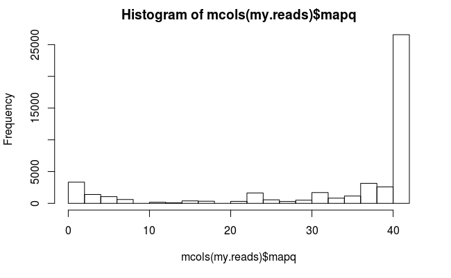

However, there are more-sophisticated visualisation options for aligned reads and range data. We will use the `ggbio` package, which first requires some discussion of the `ggplot2` plotting package.

## Brief Introduction to ggplot2

The [`ggplot2`](http://ggplot2.tidyverse.org/) package has emerged as an attractive alternative to the traditional plots provided by base R. A full overview of all capabilities of the package is available from the [cheatsheet](https://www.rstudio.com/wp-content/uploads/2015/03/ggplot2-cheatsheet.pdf).

A simple scatter plot, equivalent to `plotSmear` from before, can be generated as follows:-

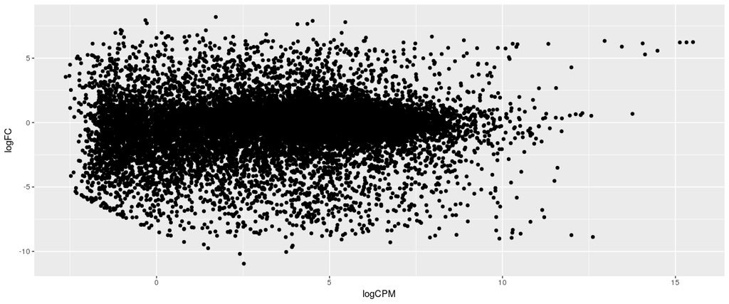

```r
library(ggplot2)
ggplot(results, aes(x = logCPM, y=logFC)) + geom_point()
```

In brief:-

- `results` is our data frame containing the variables we wish to plot
- `aes` creates a mpping between the variables in our data frame to the *aes*thetic proprties of the plot
  - the x-axis is mapped to `logCPM`, y-axis is mapped to `logFC`
- `geom_point` specifies the particular type of plot we want (in this case a scatter plot)
  - see [the cheatsheet](https://www.rstudio.com/wp-content/uploads/2015/03/ggplot2-cheatsheet.pdf) for other plot types

The real advantage of `ggplot2` is the ability to change the appearance of our plot by mapping other variables to aspects of the plot. For example, we could colour the points based on a p-value cut-off. The colours are automatically chosen by `ggplot2`, but we can specifiy particular values.

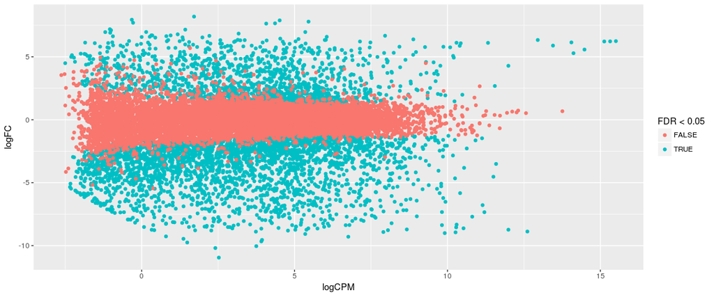

```r
ggplot(results, aes(x = logCPM, y=logFC,col=FDR < 0.05)) + geom_point()
```

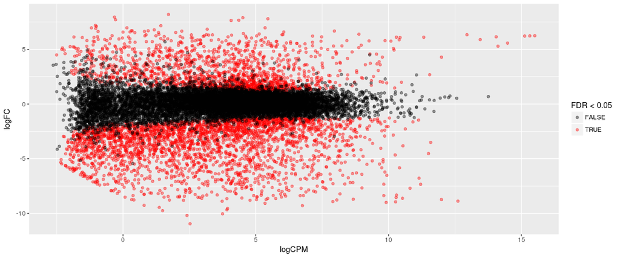

```r
ggplot(results, aes(x = logCPM, y=logFC,col=FDR < 0.05)) + geom_point(alpha=0.4) + scale_colour_manual(values=c("black","red"))
```

The volcano plot can be constructed in a similar manner

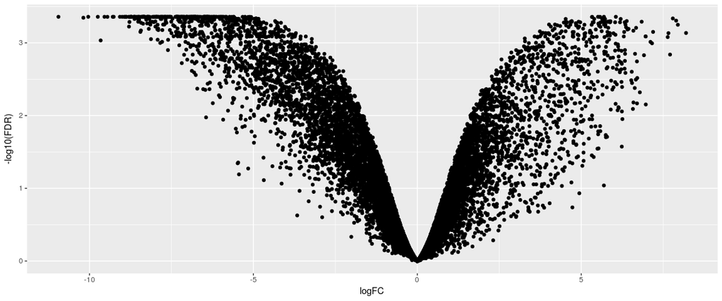

```r
ggplot(results, aes(x = logFC, y=-log10(FDR))) + geom_point()
```

## Composing plots with ggbio

We will now take a brief look at one of the visualisation packages in Bioconductor that takes advantage of the GenomicRanges and GenomicFeatures object-types. In this section we will show a worked example of how to combine several types of genomic data on the same plot. The documentation for ggbio is very extensive and contains lots of examples.

http://www.tengfei.name/ggbio/docs/

The `Gviz` package is another Bioconductor package that specialising in genomic visualisations, but we will not explore this package in the course.

The Manhattan plot is a common way of visualising genome-wide results, especially when one is concerned with the results of a GWAS study and identifying strongly-associated hits.

The profile is supposed to resemble the Manhattan skyline with particular skyscrapers towering about the lower level buildings.

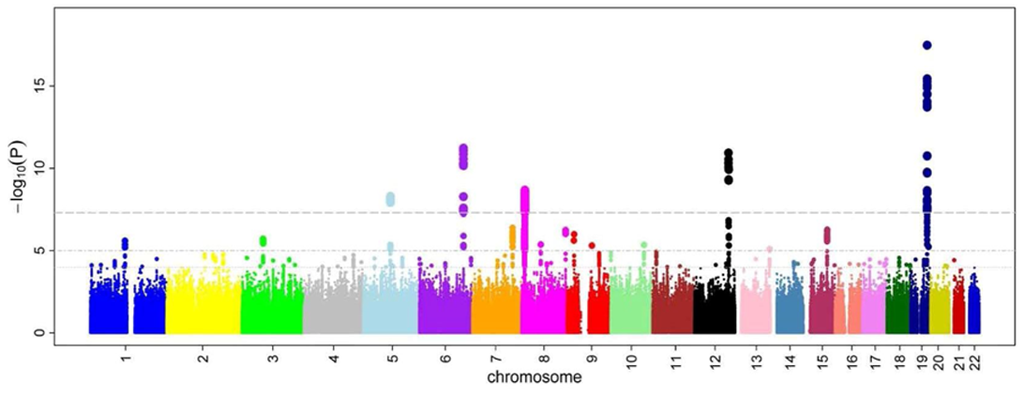

This type of plot is implemented as the `plotGrandLinear` function. We have to supply a value to display on the y-axis using the `aes` function, which is inherited from ggplot2. The positioning of points on the x-axis is handled automatically by ggbio, using the ranges information to get the genomic coordinates of the ranges of interest.

To stop the plots from being too cluttered we will consider the top 200 genes only.

```
using coord:genome to parse x scale
```

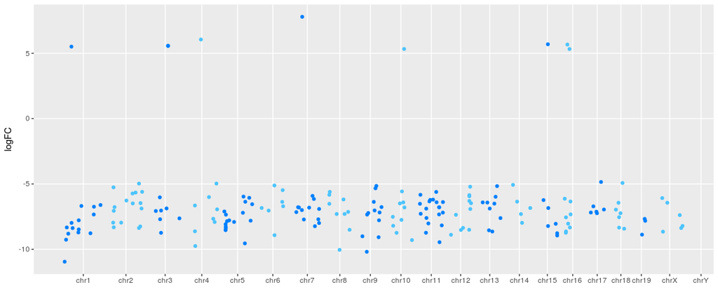

```r
library(ggbio)
top200 <- sigRegions[order(sigRegions$LR,decreasing = TRUE)[1:200]]
plotGrandLinear(top200 , aes(y = logFC))
```

`ggbio` has alternated the colours of the chromosomes. However, an appealing feature of `ggplot2` is the ability to map properties of your plot to variables present in your data. For example, we could create a variable to distinguish between up- and down-regulated genes. The variables used for aesthetic mapping must be present in the `mcols` section of your ranges object.

```
using coord:genome to parse x scale
```

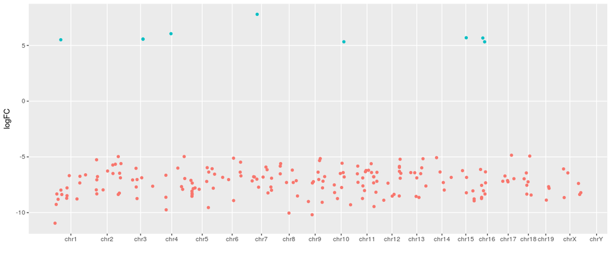

```r
mcols(top200)$UpRegulated <- mcols(top200)$logFC > 0
plotGrandLinear(top200, aes(y = logFC, col = UpRegulated))
```

`plotGrandLinear` is a special function in `ggbio` with preset options for the manhattan style of plot. More often, users will call the `autoplot` function and `ggbio` will choose the most appropriate layout. One such layout is the *karyogram*.

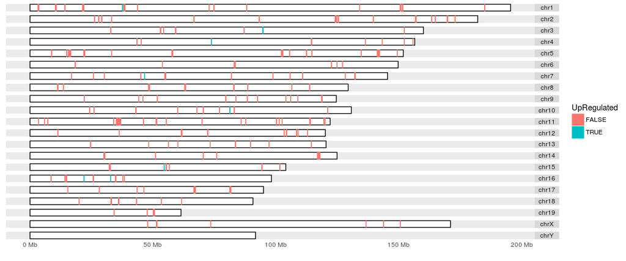

```r
autoplot(top200,layout="karyogram",aes(color=UpRegulated,
                                       fill=UpRegulated))
```

`ggbio` is also able to plot the structure of genes according to a particular model represented by a `GenomicFeatures` object, such as the object we created earlier with the exon coordinates for each gene in the mm10 genome.

```
Parsing transcripts...
Parsing exons...
Parsing cds...
Parsing utrs...
------exons...
------cdss...
------introns...
------utr...
aggregating...
Done
Constructing graphics...
```

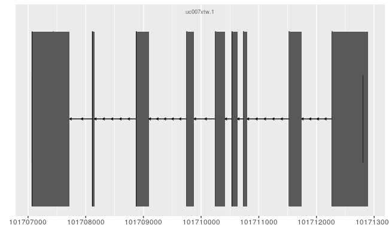

```r
autoplot(tx, which=exo[["110308"]])
```

We can even plot the location of sequencing reads if they have been imported using readGAlignments function (or similar). We can also add some flanking region around the gene if we wish.

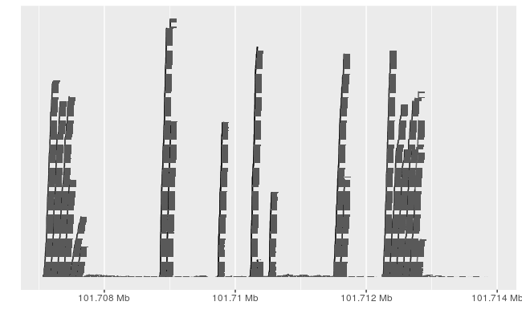

```
extracting information...
```

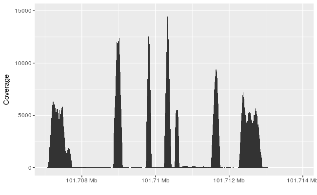

```r
autoplot(bam , stat = "coverage")
```

Like ggplot2, ggbio plots can be saved as objects that can later be modified, or combined together to form more complicated plots. If saved in this way, the plot will only be displayed on a plotting device when we query the object. This strategy is useful when we want to add a common element (such as an ideogram) to a plot composition and don’t want to repeat the code to generate the plot every time.

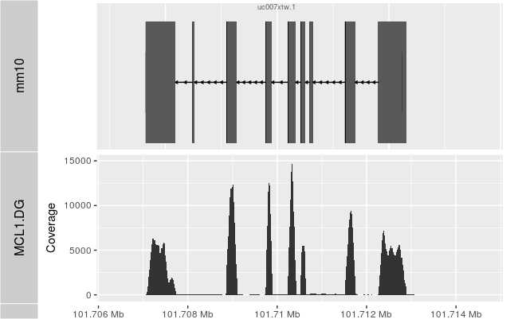

## Challenge

> Create tracks to compare the coverage of the gene Krt5 for the samples MCL1.DG, MCL1.DH, MCL1.LA and MCL1.LB

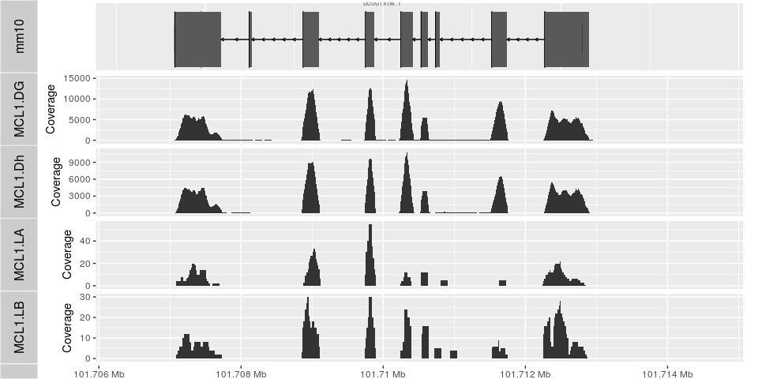